# Bio4158/Bio5158 - Report 6

- Show All Code
- Hide All Code
- View Source

Exercise

Author

Group 22 - Nalan Kurnaz

Published

November 12, 2025

# Background

For normal cells, lack of oxygen (hypoxia) results in cell death. Yet some cancer cells can continue to grow and replicate under low oxygen conditions. Not surprisingly, this observation has lead researchers to investigate how cancer cells tolerate hypoxic conditions. Recently, attention has focused on **two genes: HIF1 and HIF2**. **Exposure of both normal and cancer cells** to hypoxia results in these genes being turned on, which in turn results in the corresponding HIF1 and HIF2 transcription factors being produced. (Transcription factors are **proteins that bind to DNA and, by so doing, allow RNA synthesis to occur**.) The presence of the transcription factor then **allows normal transcription to occur** and **the cell to continue to grow and divide despite low oxygen levels**.

These data have led to the suggestion that in solid cancers (such as breast cancer), adaptation to hypoxia arises from these transcription factors being over expressed. That is, compared to normal cells, under hypoxic conditions **many more HIF1 and/or HIF2 transcripts are produced in cancer cells than in normal cells**. The larger number of transcripts produced by cancer cells makes it much more likely that normal transcription can take place. In normal cells, however, under extreme hypoxia, few HIF1 or HIF2 transcripts are produced, with the result that normal transcription often does not occur, leading to cell death.

Based on the above, we can propose several biological hypotheses, one of which is:

Cancer cell survival under hypoxic conditions occurs due to the overexpression of both HIF1 and HIF2.

To test this hypothesis, a research team sets up an experiment. In this experiment, gene-silencing mutants were developed for the breast cancer cell lines, resulting in four different cell lines:

- HIF 1+/2+ (normal forms of both genes)
- HIF 1-/2+ (HIF1 silenced, HIF2 normal)
- HIF 1+/2- (HIF1 normal, HIF2 silenced)
- HIF 1-/2- (both HIF1 and HIF2 silenced).

The HIF1- mutant cannot produce any HIF1 transcripts, and the HIF2 mutant cannot produce any HIF2 transcripts.

Ten cultures of each strain were then grown **under normal and 10 under hypoxic conditions**, and **the average growth rate (r, measured as the number of cell division per hour)** was estimated. **r > 0 indicates that the cell line will survive**.

# The data

The file `hypoxia_uottawa.csv` contains the results of this experiment. The three variables are:

- genotype (HIF1+/HIF2+, HIF1+/HIF2-, HIF1-/HIF2+, HIF1-/HIF2-)
- environment (normoxic, hypoxic) - fixed effect
- growth rate r.

# The task

Analyze the data obtained by researchers to test the hypothesis that both HIF1 overexpression and HIF2 overexpression are necessary for cancer cell survival under hypoxic conditions. In your answer, you should provide:

1. A description of the data including: the identity of the dependent and independent variables, whether the latter are fixed/random, crossed (i.e. factorial) or nested, and the identity of the levels of each. Also indicate whether there is replication or not within the individual combinations, and if there is replication, whether the design is balanced or unbalanced. *(4 points)*
2. A box plot of the data by treatment combinations (i.e. for the different genotypes and both oxygen levels) and a visual interpretation (i.e. description) of the apparent effects of your independent variables. *(3 points)*
3. A statement of the model you are going to fit (i.e. what type of ANOVA) and the corresponding null hypotheses. *(4 points)*
4. Fit the model and provide some evidence (plots, tests, and/or statements) that you examined the statistical assumptions underlying a parametric model and what you conclude. *(3 points)*
5. The results/statistical conclusion (i.e. inference) you make from your analysis (*i.e.* do you accept or reject each of the null hypotheses). With reference to the biological hypothesis in the question, explain what follow-up tests you do and why, give the results of these tests, and explain what you conclude from them *(7 points)*.
6. The “biological” conclusion, here a qualified statement about cancer cell survival under hypoxic conditions, including an estimate of effect size, its precision, and whether an effect of this magnitude is likely to matter *(3 points)*.
7. A statement about your confidence in the statistical conclusion (for example with respect to the violation of assumptions, to potential biases created by missing data, to suboptimal experimental design, and/or to power issues). *(1 point)*

# Report

### Data Preprocessing

```r
#install.packages("effects")
```

```r
library(car)
library(tidyverse)
library(effects)
data_hypoxia <- read.csv("https://raw.githubusercontent.com/nalank1/r-files/refs/heads/main/data-bioxx58/hypoxia_uottawa.csv", header = TRUE, sep = ",", stringsAsFactors = TRUE)
```

## b. A box plot of the data by treatment combinations (i.e. for the different genotypes and both oxygen levels) and a visual interpretation (i.e. description) of the apparent effects of your independent variables.

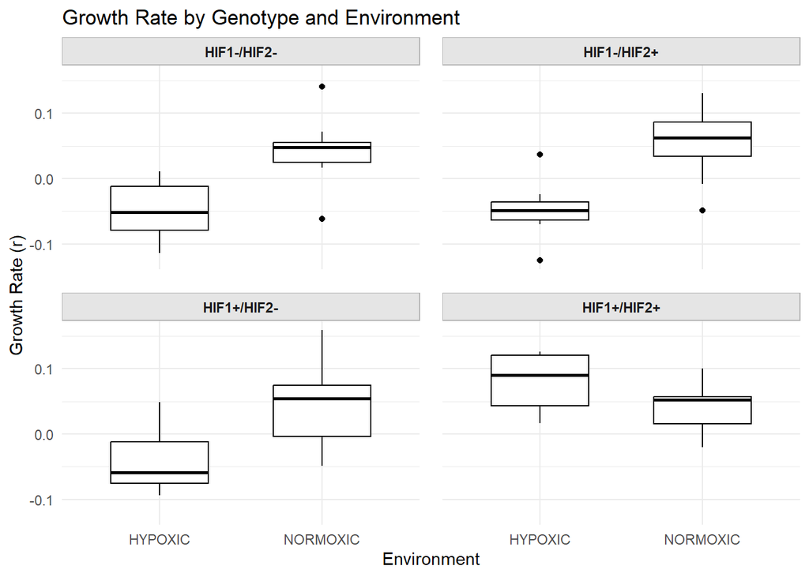

```r
ggplot(data_hypoxia, aes(x = environment, y = r, fill = environment)) +
  geom_boxplot(notch = FALSE, fill = "white", color = "black", width = 0.6) +
  facet_wrap(~genotype, ncol = 2, nrow = 2) +
  labs(
    title = "Growth Rate by Genotype and Environment",
    x = "Environment",
    y = "Growth Rate (r)"
  ) +
  theme_minimal() +
  theme(
    strip.background = element_rect(fill = "grey90", color = "grey70"),
    strip.text = element_text(face = "bold"),
    panel.spacing = unit(1, "lines"),
    legend.position = "none"
  )
```

## d. Fit the model and provide some evidence (plots, tests, and/or statements) that you examined the statistical assumptions underlying a parametric model and what you conclude.

```r
anova.model1 <- aov(r ~ genotype + environment + genotype : environment, data = data_hypoxia)
summary(anova.model1)
```

```
                     Df  Sum Sq Mean Sq F value   Pr(>F)
genotype              3 0.05694 0.01898   8.188 9.22e-05 ***
environment           1 0.06910 0.06910  29.812 6.43e-07 ***
genotype:environment  3 0.06274 0.02091   9.023 3.79e-05 ***
Residuals            72 0.16689 0.00232
---
Signif. codes:  0 '***' 0.001 '**' 0.01 '*' 0.05 '.' 0.1 ' ' 1
```

```r
Anova(anova.model1, type = 3)
```

```
Anova Table (Type III tests)

Response: r
                       Sum Sq Df F value    Pr(>F)
(Intercept)          0.020965  1  9.0446  0.003627 **
genotype             0.118837  3 17.0895 1.762e-08 ***
environment          0.039363  1 16.9818 9.964e-05 ***
genotype:environment 0.062742  3  9.0226 3.790e-05 ***
Residuals            0.166892 72
---
Signif. codes:  0 '***' 0.001 '**' 0.01 '*' 0.05 '.' 0.1 ' ' 1
```

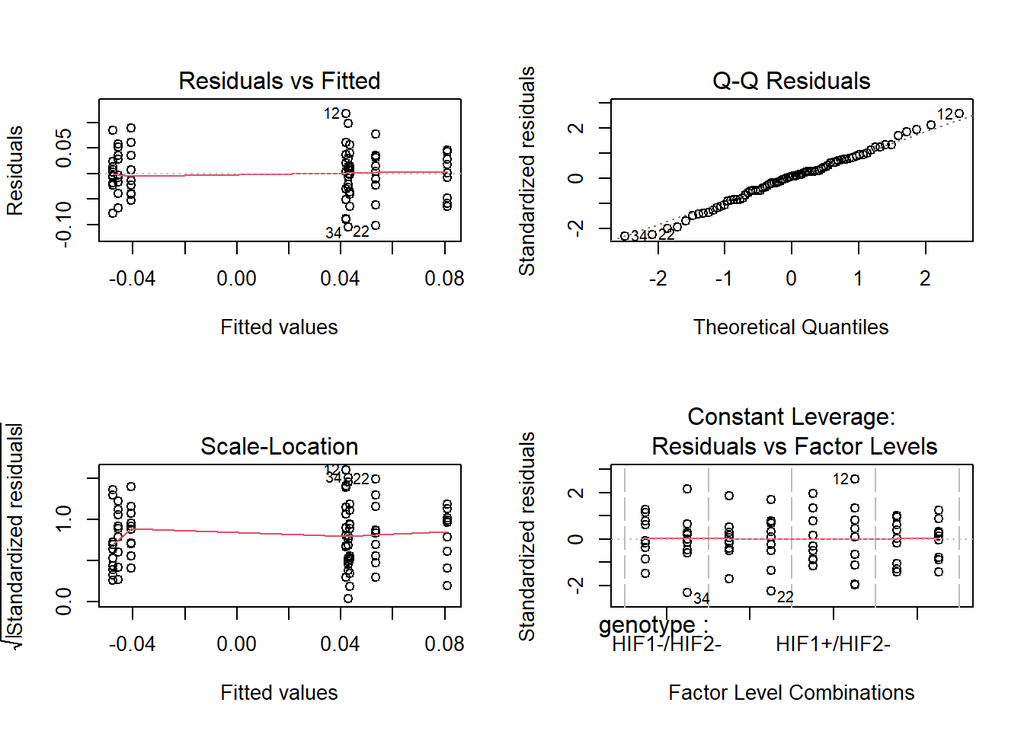

```r
par(mfrow = c(2,2))
plot(anova.model1)
```

```r
# normality
shapiro.test(residuals(anova.model1))
```

```
    Shapiro-Wilk normality test

data:  residuals(anova.model1)
W = 0.9928, p-value = 0.9386
```

```r
# for homogeneity
leveneTest(r ~ genotype * environment, data = data_hypoxia)
```

```
Levene's Test for Homogeneity of Variance (center = median)
      Df F value Pr(>F)
group  7  0.5988 0.7549
      72
```

To fully verify the normality, Shapiro Test was calculated. The test resulted in having p-value of 0.9386, meaning that it is failing to reject the null hypothesis that the data is normally distributed. The normality assumption is met and verified. To verify the homogeneity of the variance, Levene Test was used. The test resulted in f-value of 0.5988 and p-value of 0.7549. Since p-value is bigger than 0.05, we are failing to reject the null hypothesis that the data is homoscedastic, meaning the data is homoscedastic. For the independence, we can assume that the data points are independent. Since the model assumptions are met, we proceeded by fitting the model in ANOVA. As seen in ANOVA outputs, we can see that all factors’ p-values are considerably lower than 0.05, and this indicates that all three null hypothesis are rejected. In other words, there is an effect of genotype, environment and interaction (genotype and environment) on the growth rate.

```r
allEffects(anova.model1)
```

```
 model: r ~ genotype + environment + genotype:environment

 genotype*environment effect
             environment
genotype          HYPOXIC   NORMOXIC
  HIF1-/HIF2- -0.04578750 0.04293992
  HIF1-/HIF2+ -0.04783963 0.05337157
  HIF1+/HIF2- -0.04064659 0.04207791
  HIF1+/HIF2+  0.08097338 0.04343210
```

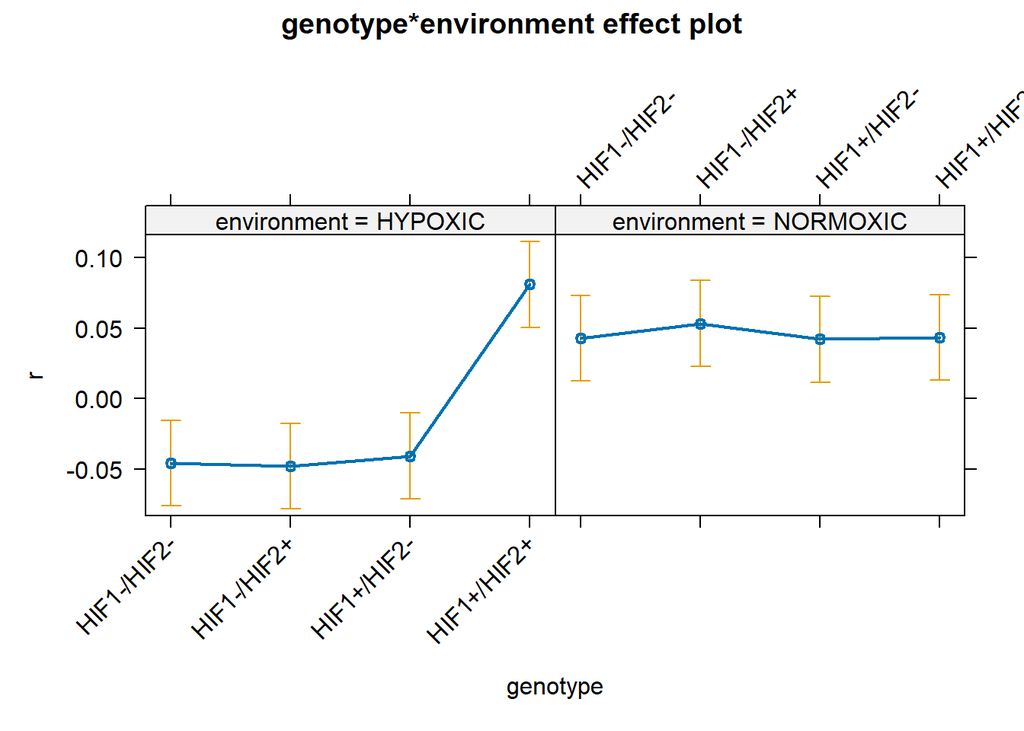

```r
plot(allEffects(anova.model1), "genotype:environment", rotx = 45)
```

```r
#follow up test
tukey.result1 <- TukeyHSD(anova.model1, which = "genotype")
tukey.result1
```

```
  Tukey multiple comparisons of means
    95% family-wise confidence level

Fit: aov(formula = r ~ genotype + environment + genotype:environment, data = data_hypoxia)

$genotype
                                diff         lwr        upr     p adj
HIF1-/HIF2+-HIF1-/HIF2-  0.004189762 -0.03585238 0.04423190 0.9926565
HIF1+/HIF2--HIF1-/HIF2-  0.002139450 -0.03790269 0.04218159 0.9990007
HIF1+/HIF2+-HIF1-/HIF2-  0.063626531  0.02358439 0.10366867 0.0004632
HIF1+/HIF2--HIF1-/HIF2+ -0.002050312 -0.04209245 0.03799183 0.9991199
HIF1+/HIF2+-HIF1-/HIF2+  0.059436769  0.01939463 0.09947891 0.0011858
HIF1+/HIF2+-HIF1+/HIF2-  0.061487081  0.02144494 0.10152922 0.0007522
```

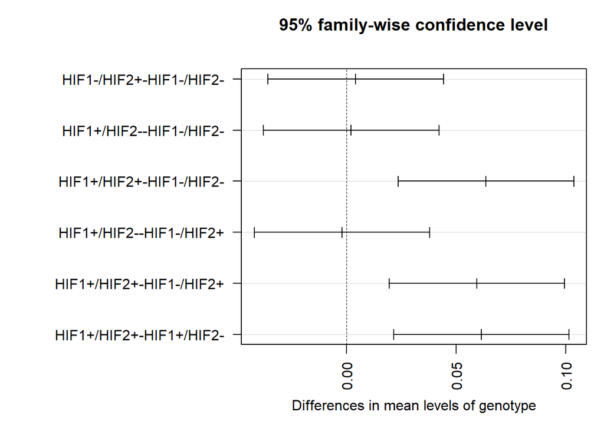

```r
par(mar = c(5, 14, 4, 1))
plot(tukey.result1, las = 2)
```

```r
tukey.result3 <- TukeyHSD(anova.model1, which = "genotype:environment")
tukey.result3
```

```
  Tukey multiple comparisons of means
    95% family-wise confidence level

Fit: aov(formula = r ~ genotype + environment + genotype:environment, data = data_hypoxia)

$`genotype:environment`
                                                   diff         lwr        upr
HIF1-/HIF2+:HYPOXIC-HIF1-/HIF2-:HYPOXIC   -0.0020521292 -0.06926813 0.06516387
HIF1+/HIF2-:HYPOXIC-HIF1-/HIF2-:HYPOXIC    0.0051409132 -0.06207508 0.07235691
HIF1+/HIF2+:HYPOXIC-HIF1-/HIF2-:HYPOXIC    0.1267608772  0.05954488 0.19397687
HIF1-/HIF2-:NORMOXIC-HIF1-/HIF2-:HYPOXIC   0.0887274203  0.02151142 0.15594342
HIF1-/HIF2+:NORMOXIC-HIF1-/HIF2-:HYPOXIC   0.0991590729  0.03194308 0.16637507
HIF1+/HIF2-:NORMOXIC-HIF1-/HIF2-:HYPOXIC   0.0878654075  0.02064941 0.15508141
HIF1+/HIF2+:NORMOXIC-HIF1-/HIF2-:HYPOXIC   0.0892196049  0.02200361 0.15643560
HIF1+/HIF2-:HYPOXIC-HIF1-/HIF2+:HYPOXIC    0.0071930424 -0.06002296 0.07440904
HIF1+/HIF2+:HYPOXIC-HIF1-/HIF2+:HYPOXIC    0.1288130064  0.06159701 0.19602900
HIF1-/HIF2-:NORMOXIC-HIF1-/HIF2+:HYPOXIC   0.0907795495  0.02356355 0.15799555
HIF1-/HIF2+:NORMOXIC-HIF1-/HIF2+:HYPOXIC   0.1012112021  0.03399520 0.16842720
HIF1+/HIF2-:NORMOXIC-HIF1-/HIF2+:HYPOXIC   0.0899175367  0.02270154 0.15713353
HIF1+/HIF2+:NORMOXIC-HIF1-/HIF2+:HYPOXIC   0.0912717341  0.02405574 0.15848773
HIF1+/HIF2+:HYPOXIC-HIF1+/HIF2-:HYPOXIC    0.1216199640  0.05440397 0.18883596
HIF1-/HIF2-:NORMOXIC-HIF1+/HIF2-:HYPOXIC   0.0835865071  0.01637051 0.15080250
HIF1-/HIF2+:NORMOXIC-HIF1+/HIF2-:HYPOXIC   0.0940181597  0.02680216 0.16123416
HIF1+/HIF2-:NORMOXIC-HIF1+/HIF2-:HYPOXIC   0.0827244943  0.01550850 0.14994049
HIF1+/HIF2+:NORMOXIC-HIF1+/HIF2-:HYPOXIC   0.0840786917  0.01686269 0.15129469
HIF1-/HIF2-:NORMOXIC-HIF1+/HIF2+:HYPOXIC  -0.0380334569 -0.10524945 0.02918254
HIF1-/HIF2+:NORMOXIC-HIF1+/HIF2+:HYPOXIC  -0.0276018043 -0.09481780 0.03961419
HIF1+/HIF2-:NORMOXIC-HIF1+/HIF2+:HYPOXIC  -0.0388954697 -0.10611147 0.02832053
HIF1+/HIF2+:NORMOXIC-HIF1+/HIF2+:HYPOXIC  -0.0375412723 -0.10475727 0.02967473
HIF1-/HIF2+:NORMOXIC-HIF1-/HIF2-:NORMOXIC  0.0104316526 -0.05678435 0.07764765
HIF1+/HIF2-:NORMOXIC-HIF1-/HIF2-:NORMOXIC -0.0008620128 -0.06807801 0.06635398
HIF1+/HIF2+:NORMOXIC-HIF1-/HIF2-:NORMOXIC  0.0004921846 -0.06672381 0.06770818
HIF1+/HIF2-:NORMOXIC-HIF1-/HIF2+:NORMOXIC -0.0112936654 -0.07850966 0.05592233
HIF1+/HIF2+:NORMOXIC-HIF1-/HIF2+:NORMOXIC -0.0099394680 -0.07715547 0.05727653
HIF1+/HIF2+:NORMOXIC-HIF1+/HIF2-:NORMOXIC  0.0013541974 -0.06586180 0.06857020
                                              p adj
HIF1-/HIF2+:HYPOXIC-HIF1-/HIF2-:HYPOXIC   1.0000000
HIF1+/HIF2-:HYPOXIC-HIF1-/HIF2-:HYPOXIC   0.9999976
HIF1+/HIF2+:HYPOXIC-HIF1-/HIF2-:HYPOXIC   0.0000031
HIF1-/HIF2-:NORMOXIC-HIF1-/HIF2-:HYPOXIC  0.0024157
```

[output cut: 9 more lines]

```
HIF1+/HIF2+:HYPOXIC-HIF1+/HIF2-:HYPOXIC   0.0000082
HIF1-/HIF2-:NORMOXIC-HIF1+/HIF2-:HYPOXIC  0.0053128
HIF1-/HIF2+:NORMOXIC-HIF1+/HIF2-:HYPOXIC  0.0010371
HIF1+/HIF2-:NORMOXIC-HIF1+/HIF2-:HYPOXIC  0.0060422
HIF1+/HIF2+:NORMOXIC-HIF1+/HIF2-:HYPOXIC  0.0049343
HIF1-/HIF2-:NORMOXIC-HIF1+/HIF2+:HYPOXIC  0.6442350
HIF1-/HIF2+:NORMOXIC-HIF1+/HIF2+:HYPOXIC  0.9025889
HIF1+/HIF2-:NORMOXIC-HIF1+/HIF2+:HYPOXIC  0.6178315
HIF1+/HIF2+:NORMOXIC-HIF1+/HIF2+:HYPOXIC  0.6591572
HIF1-/HIF2+:NORMOXIC-HIF1-/HIF2-:NORMOXIC 0.9996985
HIF1+/HIF2-:NORMOXIC-HIF1-/HIF2-:NORMOXIC 1.0000000
HIF1+/HIF2+:NORMOXIC-HIF1-/HIF2-:NORMOXIC 1.0000000
HIF1+/HIF2-:NORMOXIC-HIF1-/HIF2+:NORMOXIC 0.9994908
HIF1+/HIF2+:NORMOXIC-HIF1-/HIF2+:NORMOXIC 0.9997814
HIF1+/HIF2+:NORMOXIC-HIF1+/HIF2-:NORMOXIC 1.0000000
```

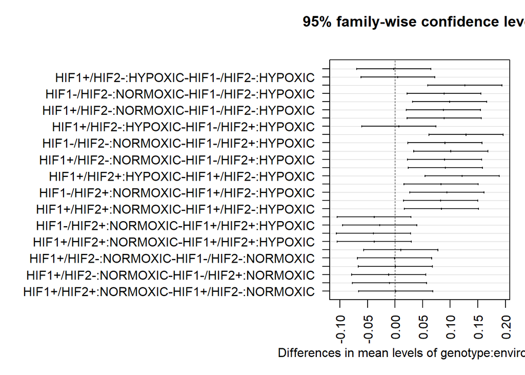

```r
par(mar = c(5, 22, 4, 1))
plot(tukey.result3, las = 2)
```

On the interaction plot, we can see that lines are not parallel, meaning there is an effect of interaction of environment and genotype on the growth rate. We can also see that means of genotypes are different, meaning genotype has an effect on the growth rate. In addition to that, we can see the means of environment differ by hypoxic and normoxic, indicating that the environment has an effect on the growth rate too. This aligns with our rejection of null hypothesis.

As seen in the first follow up test (on Genotype), we can see that HIF1+/HIF2+ has a higher mean than the rest of the genotypes. 95% family wise confidence levels of ((HIF1+/HIF2+ - HIF1-/HIF2-), (HIF1+/HIF2+ - HIF1-/HIF2+) and (HIF1+/HIF2+ - HIF1+/HIF2-)) don’t contain zero, meaning the difference between those two genotype means is statistically significant. This does support our biological hypothesis (overexpression of both genes) as well.

The follow up test (on environment) was not needed since it only had two levels.

The third follow up test was the Tukey’s HSD on the interaction of environment and genotype. As seen on the plot, the 95% confidence level of (HIF1+/HIF2+:HYPOXIC-HIF1-/HIF2+:HYPOXIC) seemed the highest, and then, (HIF1+/HIF2+ (Hypoxic) - HIF1-/HIF2- (Hypoxic)) came the second. Regardless of the order, we can see that HIF1+/HIF2+ gene in Hypoxic condition have a mean growth rate that is larger than the other genotypes.

## e. The results/statistical conclusion (i.e. inference) you make from your analysis (i.e. do you accept or reject each of the null hypotheses). With reference to the biological hypothesis in the question, explain what follow-up tests you do and why, give the results of these tests, and explain what you conclude from them.

The analysis of a Two-way ANOVA testing the effects of Genotype, Environment and their interaction on the growth rate directed to the rejection of all three null hypotheses.

## f. The “biological” conclusion, here a qualified statement about cancer cell survival under hypoxic conditions, including an estimate of effect size, its precision, and whether an effect of this magnitude is likely to matter.

```r
library(effectsize)
options(es.use_symbols = TRUE)

eta_squared(car::Anova(anova.model1, type = 3))
```

```
Type 3 ANOVAs only give sensible and informative results when covariates
  are mean-centered and factors are coded with orthogonal contrasts (such
  as those produced by `contr.sum`, `contr.poly`, or `contr.helmert`, but
  *not* by the default `contr.treatment`).
```

```
# Effect Size for ANOVA (Type III)

Parameter            | η² (partial) |       95% CI
--------------------------------------------------
genotype             |         0.42 | [0.26, 1.00]
environment          |         0.19 | [0.07, 1.00]
genotype:environment |         0.27 | [0.12, 1.00]

- One-sided CIs: upper bound fixed at [1.00].
```

## g. A statement about your confidence in the statistical conclusion (for example with respect to the violation of assumptions, to potential biases created by missing data, to suboptimal experimental design, and/or to power issues).

Our confidence in the statistical conclusion is high as the dataset is balanced and replicated. In addition to these, the model assumptions of normality, homoscedasticity and independence are met and verified. As it is balanced, there are no missing values, and there is enough data to verify and test our statistical conclusion. These premises increases our confidence in the statistical conclusion.

## References

1. [Used for Part b](https://ggplot2-book.org/themes.html)
2. [ChatGPT For Debugging Purposes on effects package on Part d] (Lattice package)
- Used Prompt: “Can you help me debug why this problem occurs? Error in xyplot.formula(eval(parse(text = paste(”fit ~ as.numeric(“, predictors[x.var], : formal argument”scales” matched by multiple actual arguments)))))” - gave me solution of using rotx
3. [For Part e](https://psychohawks.wordpress.com/2010/10/31/effect-size-for-analysis-of-variables-anova/)
4. [For Part e](https://cran.r-project.org/web/packages/effectsize/vignettes/anovaES.html)